# Proyecto 3: Series de Tiempo

7/7/2020

## Series de Tiempo

- Tasa de Desempleo en México
- Tasa de Desempleo en EEUU
- Datos obtenidos de la página FRED
- Desde el 2005 hasta el 2019

## EEUU

## Datos

|  | Date | Porcentaje | Periodo |
| --- | --- | --- | --- |
| 1 | 2005-01-01 | 15.9 | Antes |
| 2 | 2005-04-01 | 15.3 | Antes |
| 3 | 2005-07-01 | 14.9 | Antes |
| 4 | 2005-10-01 | 14.9 | Antes |
| 5 | 2006-01-01 | 14.2 | Antes |
| 6 | 2006-04-01 | 13.9 | Antes |
| 7 | 2006-07-01 | 13.9 | Antes |
| 8 | 2006-10-01 | 13.3 | Antes |
| 9 | 2007-01-01 | 13.5 | Antes |
| 10 | 2007-04-01 | 13.5 | Antes |

[output cut: 50 more lines]

## Visualización de los Datos

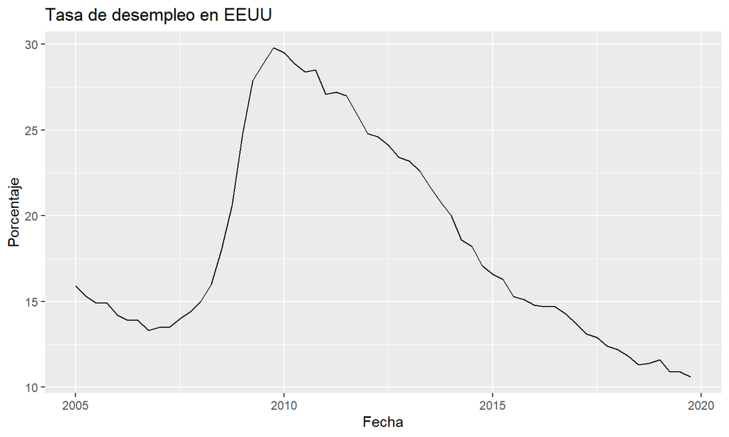

## Outliers

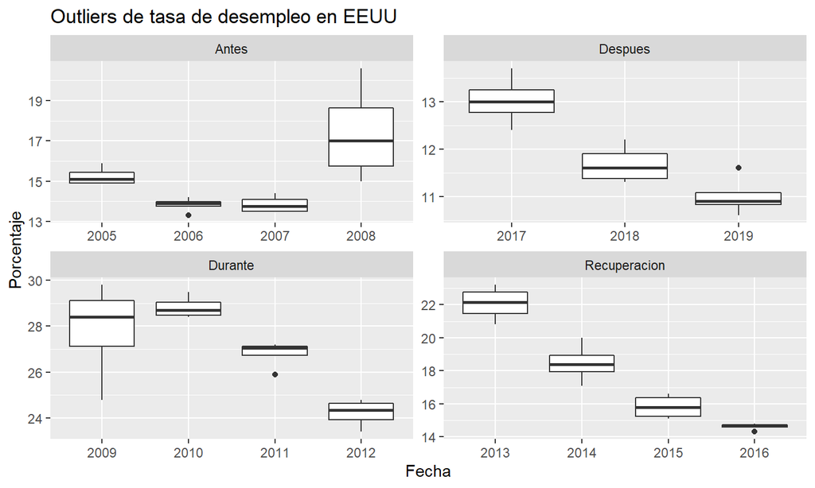

## Descomposición

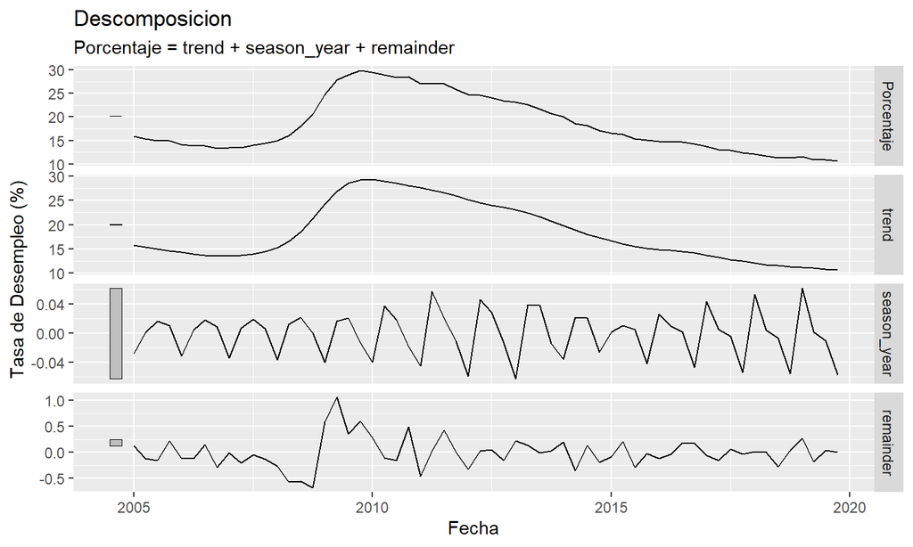

## Métodos de referencia y Suavización Exp

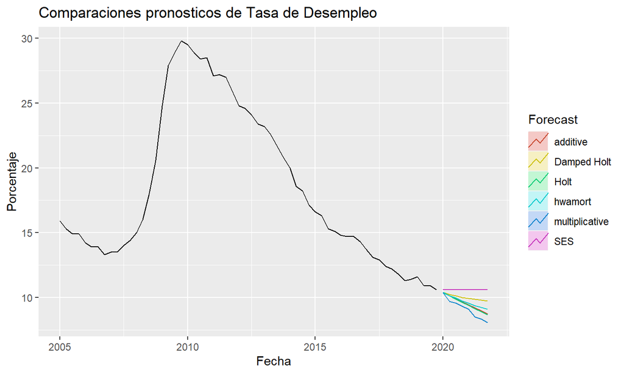

## Accuracy

Con la función de accuracy podemos ver qué tanto se ajustan los modelos o qué tan buenos son los modelos para la serie de tiempo.

|  | .model | RMSE | MAE | MAPE |
| --- | --- | --- | --- | --- |
| 1 | hwamort | 0.647946907223042 | 0.457761233369564 | 2.41498323613828 |
| 2 | additive | 0.658762910284531 | 0.491264919630638 | 2.64184872167167 |
| 3 | multiplicative | 0.850791390270899 | 0.608853470019266 | 3.20071658988774 |
| 4 | Holt | 0.650467483741297 | 0.479592520519366 | 2.57225574886693 |
| 5 | Damped Holt | 0.620703067091975 | 0.456047199087422 | 2.49320746898771 |
| 6 | SES | 0.989436322922132 | 0.655073228669225 | 3.44710629079143 |

## Pronóstico

El mejor modelo para nuestra serie de acuerdo con el MAPE es el Holt Winters Amortiguado.

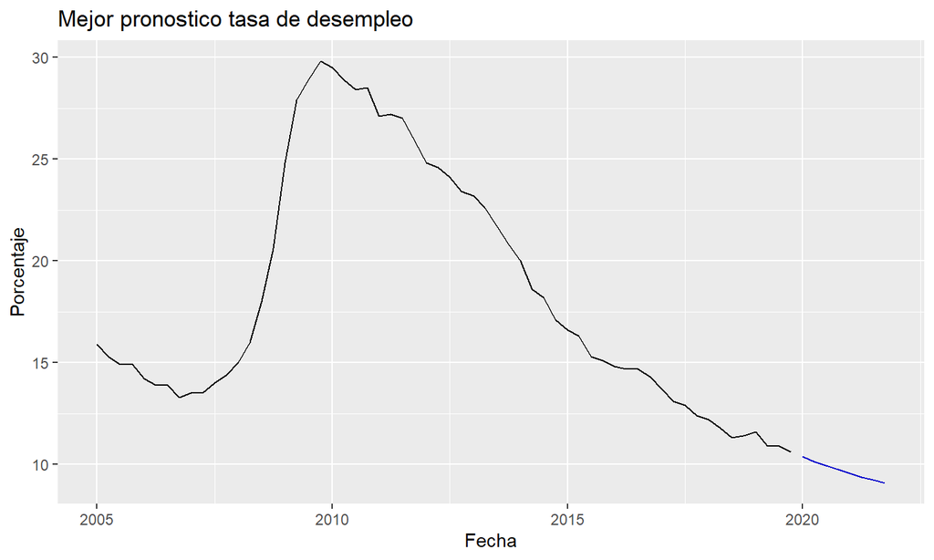

## Pruebas de raíz unitaria

```
## # A tibble: 1 x 1
##   ndiffs
##    <int>
## 1      1
```

```
## # A tibble: 1 x 1
##   nsdiffs
##     <int>
## 1       0
```

```
## # A tibble: 1 x 2
##   kpss_stat kpss_pvalue
##       <dbl>       <dbl>
## 1     0.472      0.0479
```

## Residuales

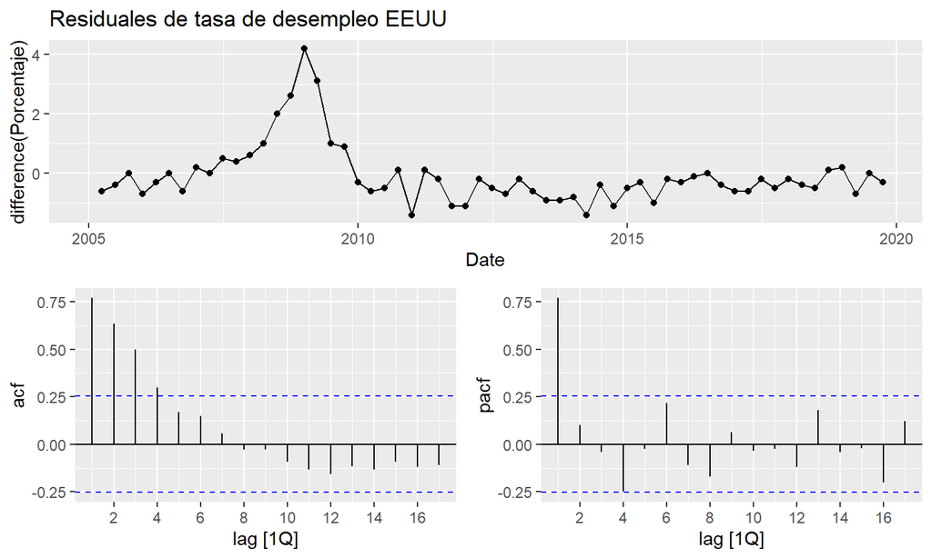

## Selección de ARIMA

```
## Series: Porcentaje
## Model: ARIMA(1,1,0)(0,0,2)[4]
##
## Coefficients:
##          ar1     sma1     sma2
##       0.8902  -0.4139  -0.3964
## s.e.  0.0708   0.1677   0.1487
##
## sigma^2 estimated as 0.3486:  log likelihood=-53.27
## AIC=114.54   AICc=115.29   BIC=122.85
```

```
## # A tibble: 7 x 8
##   .model       sigma2 log_lik   AIC  AICc   BIC ar_roots  ma_roots
##   <chr>         <dbl>   <dbl> <dbl> <dbl> <dbl> <list>    <list>
## 1 arima010_101  0.926   -80.6  167.  168.  174. <cpl [4]> <cpl [4]>
## 2 arima111_100  0.411   -56.4  121.  122.  129. <cpl [5]> <cpl [1]>
## 3 arima012_001  0.525   -63.5  135.  136.  143. <cpl [0]> <cpl [6]>
## 4 arima011_001  0.565   -66.2  138.  139.  145. <cpl [0]> <cpl [5]>
## 5 arima112_100  0.411   -55.9  122.  123.  132. <cpl [5]> <cpl [2]>
## 6 arima110_002  0.349   -53.3  115.  115.  123. <cpl [1]> <cpl [8]>
## 7 arima011_101  0.575   -66.2  140.  141.  149. <cpl [4]> <cpl [5]>
```

## Residuales del modelo seleccionado

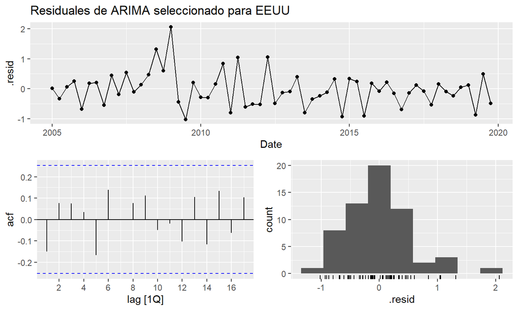

## Pronóstico ARIMA

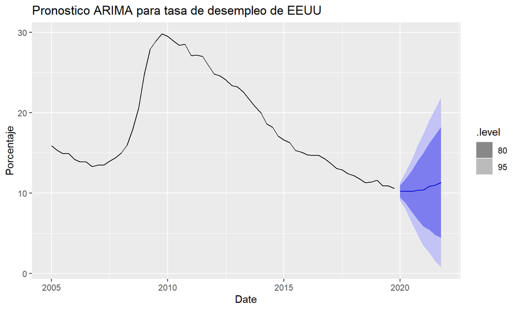

## Interpretaciones

- Se nota una tasa alrededor del 15% en la normalidad, alterada por la crisis del 2008 y recuperándose desde entonces.
- Nuestras pronósticos apuntan a la disminución de la tasa durante el año, complicado por la pandemia actual.
- ARIMA nos da una predicción poco arriba del 10% para este año, con rango entre 5% y 17%.

## México

## Datos

|  | Date | Porcentaje | Periodo |
| --- | --- | --- | --- |
| 1 | 2005-01-01 | 3.8129764299239 | Antes |
| 2 | 2005-04-01 | 3.83344105866485 | Antes |
| 3 | 2005-07-01 | 3.61130076563887 | Antes |
| 4 | 2005-10-01 | 3.45210265138407 | Antes |
| 5 | 2006-01-01 | 3.48822716191447 | Antes |
| 6 | 2006-04-01 | 3.50117745695894 | Antes |
| 7 | 2006-07-01 | 3.82202421497254 | Antes |
| 8 | 2006-10-01 | 3.9158811274169 | Antes |
| 9 | 2007-01-01 | 3.93093919530439 | Antes |
| 10 | 2007-04-01 | 3.68958340121028 | Antes |

[output cut: 51 more lines]

## Visualización de los Datos

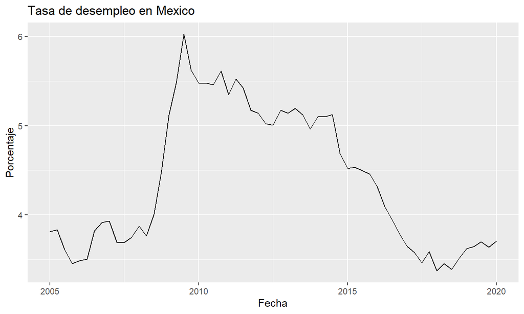

## Outliers

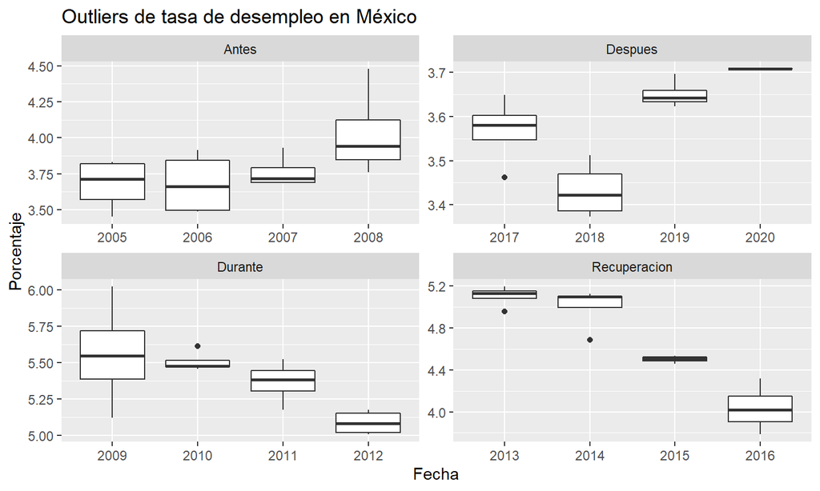

## Descomposición

Parece que tiene estacionalidad pero al momento de hacer el ARIMA se demuestra lo contrario.

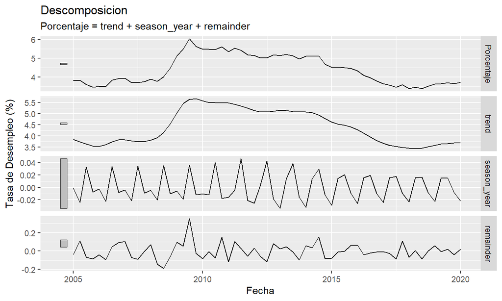

## Métodos de referencia y Suavización Exp

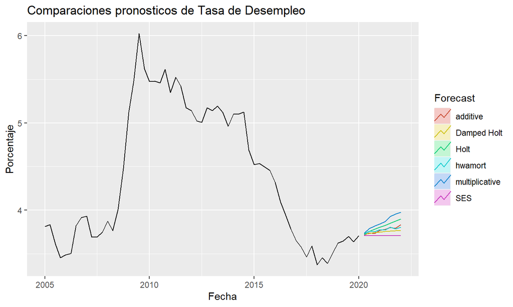

## Accuracy

Con la función de accuracy podemos ver qué tanto se ajustan los modelos o qué tan buenos son los modelos para la serie de tiempo.

|  | .model | RMSE | MAPE | MAE |
| --- | --- | --- | --- | --- |
| 1 | hwamort | 0.187857826355296 | 3.1226431455577 | 0.138312706901735 |
| 2 | additive | 0.203818286482723 | 3.34700742339485 | 0.148754557625714 |
| 3 | multiplicative | 0.203291607918123 | 3.28684908285619 | 0.144476526426699 |
| 4 | Holt | 0.2067999199751 | 3.33318134523393 | 0.147421730645095 |
| 5 | Damped Holt | 0.1915901493396 | 3.14016560509478 | 0.139418529757671 |
| 6 | SES | 0.197033890019522 | 3.18266977020561 | 0.141659544813785 |

## Pronóstico

El mejor modelo para nuestra serie de acuerdo con el MAPE es el Holt Winters Amortiguado.

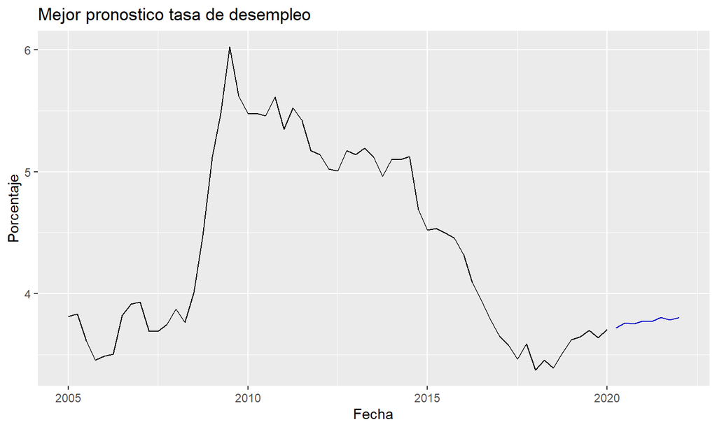

## Pruebas de raíz unitaria

```
## # A tibble: 1 x 1
##   ndiffs
##    <int>
## 1      0
```

```
## # A tibble: 1 x 1
##   nsdiffs
##     <int>
## 1       0
```

```
## # A tibble: 1 x 2
##   kpss_stat kpss_pvalue
##       <dbl>       <dbl>
## 1     0.392      0.0808
```

## Residuales

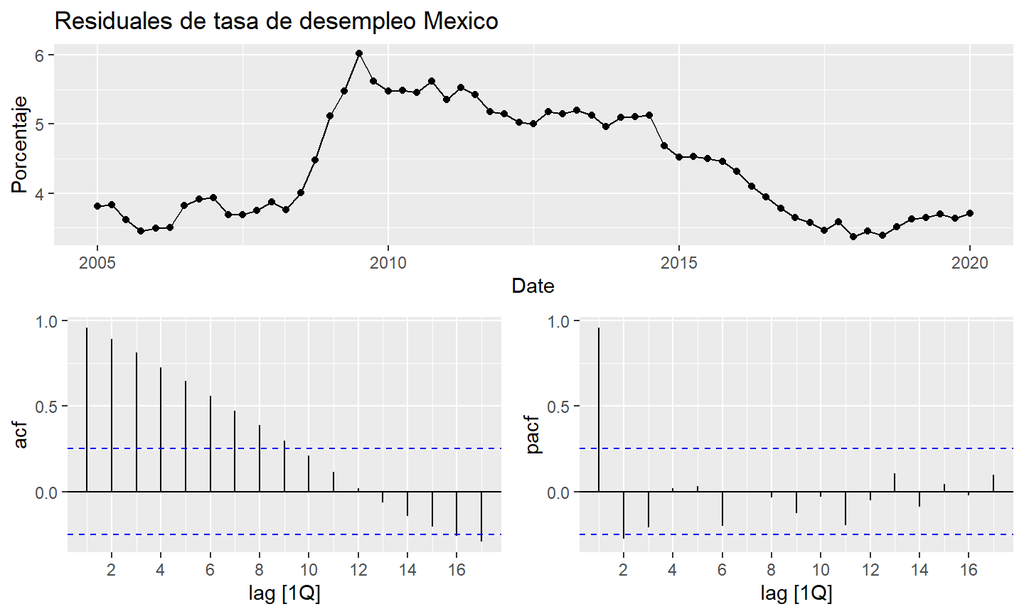

## Selección de ARIMA

```
## Series: Porcentaje
## Model: ARIMA(1,0,2) w/ mean
##
## Coefficients:
##          ar1     ma1     ma2  constant
##       0.9187  0.3244  0.4003    0.3426
## s.e.  0.0477  0.1252  0.1197    0.0337
##
## sigma^2 estimated as 0.03348:  log likelihood=17.49
## AIC=-24.99   AICc=-23.9   BIC=-14.43
```

```
## # A tibble: 7 x 8
##   .model   sigma2 log_lik   AIC  AICc   BIC ar_roots  ma_roots
##   <chr>     <dbl>   <dbl> <dbl> <dbl> <dbl> <list>    <list>
## 1 arima100 0.0398    11.5 -17.0 -16.6 -10.7 <cpl [1]> <cpl [0]>
## 2 arima101 0.0375    13.8 -19.5 -18.8 -11.1 <cpl [1]> <cpl [1]>
## 3 arima102 0.0335    17.5 -25.0 -23.9 -14.4 <cpl [1]> <cpl [2]>
## 4 arima200 0.0360    15.0 -21.9 -21.2 -13.5 <cpl [2]> <cpl [0]>
## 5 arima201 0.0357    15.7 -21.4 -20.3 -10.8 <cpl [2]> <cpl [1]>
## 6 arima202 0.0341    17.5 -23.0 -21.4 -10.3 <cpl [2]> <cpl [2]>
## 7 arima001 0.206    -38.2  82.3  82.7  88.6 <cpl [0]> <cpl [1]>
```

## Residuales del modelo seleccionado

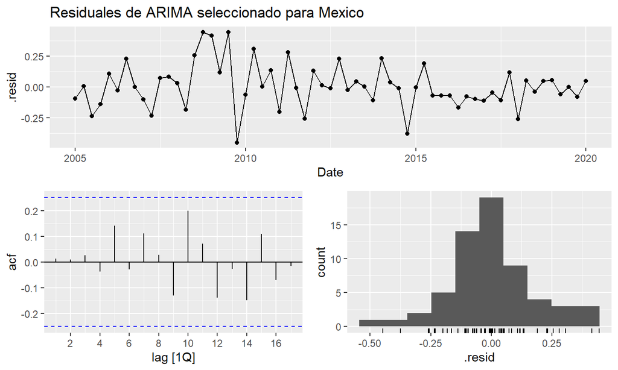

## Pronóstico ARIMA

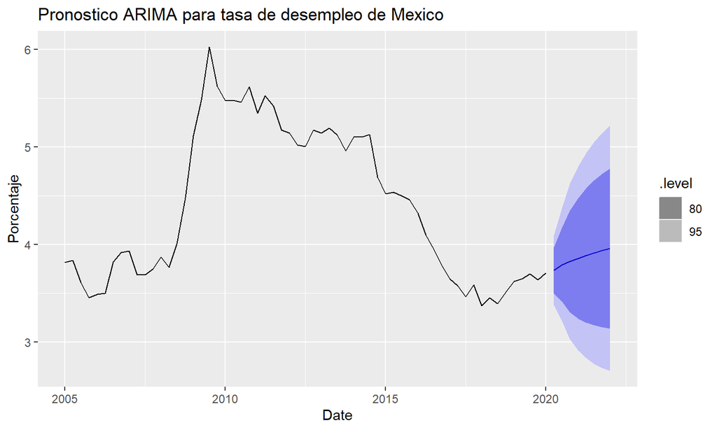

## Interpretaciones

- México tiene una menor tasa de desempleo, aún así tuvo un comportamiento muy parecido al de USA en los últimos 15 años.
- Nuestros modelos, en general, predicen una tendencia alcista hasta casi 4%.
- De la misma forma, el modelo ARIMA nos predice una subida ligeramente alcista para este año.